# individual2.Rmd

4. How do different bean origins compare in terms of the flavor of chocolates? Are beans from some places better than the other? Create both numerical and graphical summaries, and explain.

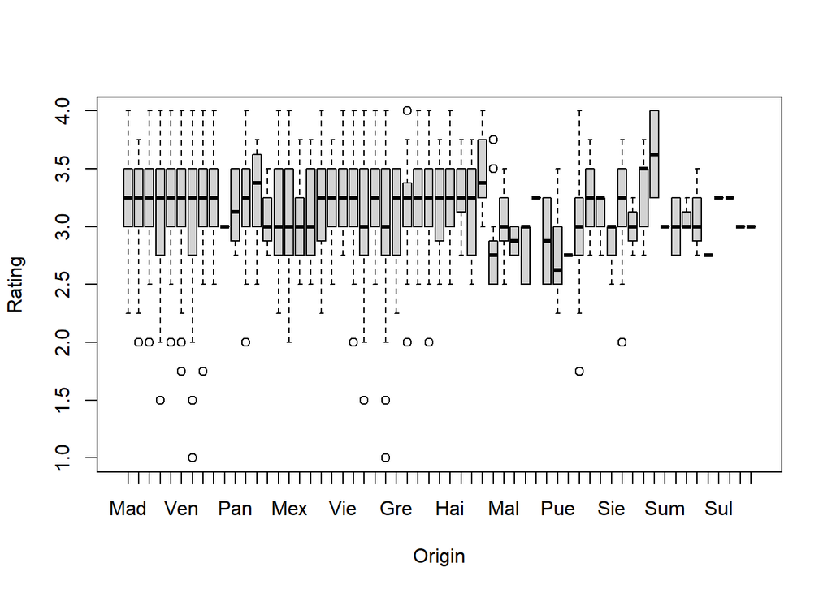

```r
e<- (choco$Rating)
f<- choco$Bean_Origin
fac<-factor(f, levels =unique(f))
levels(fac) <- substr(levels(fac), 1, 3)
boxplot(e ~ fac, xlab='Origin', ylab='Rating')
```

```r
head(sort(choco$Rating, decreasing = TRUE), n=900)
```

```
##   [1] 4.00 4.00 4.00 4.00 4.00 4.00 4.00 4.00 4.00 4.00 4.00 4.00 4.00 4.00 4.00
##  [16] 4.00 4.00 4.00 4.00 4.00 4.00 4.00 4.00 4.00 4.00 4.00 4.00 4.00 4.00 4.00
##  [31] 4.00 4.00 4.00 4.00 4.00 4.00 4.00 4.00 4.00 4.00 4.00 4.00 4.00 4.00 4.00
##  [46] 4.00 4.00 4.00 4.00 4.00 4.00 4.00 4.00 4.00 4.00 4.00 4.00 4.00 4.00 4.00
##  [61] 4.00 4.00 4.00 4.00 4.00 4.00 4.00 4.00 4.00 4.00 4.00 4.00 4.00 4.00 4.00
##  [76] 4.00 4.00 4.00 4.00 4.00 4.00 4.00 4.00 4.00 4.00 4.00 4.00 4.00 4.00 4.00
##  [91] 4.00 4.00 4.00 4.00 4.00 4.00 4.00 4.00 4.00 4.00 4.00 4.00 3.75 3.75 3.75
## [106] 3.75 3.75 3.75 3.75 3.75 3.75 3.75 3.75 3.75 3.75 3.75 3.75 3.75 3.75 3.75
## [121] 3.75 3.75 3.75 3.75 3.75 3.75 3.75 3.75 3.75 3.75 3.75 3.75 3.75 3.75 3.75
## [136] 3.75 3.75 3.75 3.75 3.75 3.75 3.75 3.75 3.75 3.75 3.75 3.75 3.75 3.75 3.75
## [151] 3.75 3.75 3.75 3.75 3.75 3.75 3.75 3.75 3.75 3.75 3.75 3.75 3.75 3.75 3.75
## [166] 3.75 3.75 3.75 3.75 3.75 3.75 3.75 3.75 3.75 3.75 3.75 3.75 3.75 3.75 3.75
## [181] 3.75 3.75 3.75 3.75 3.75 3.75 3.75 3.75 3.75 3.75 3.75 3.75 3.75 3.75 3.75
## [196] 3.75 3.75 3.75 3.75 3.75 3.75 3.75 3.75 3.75 3.75 3.75 3.75 3.75 3.75 3.75
## [211] 3.75 3.75 3.75 3.75 3.75 3.75 3.75 3.75 3.75 3.75 3.75 3.75 3.75 3.75 3.75
```

[output cut: 45 more lines]

```r
outstanding<- choco[choco$Rating >= 3.5,]
q<- outstanding['Bean_Origin']
as.data.frame(table(q))
```

```
##                      q Freq
## 1            Australia    1
## 2               Belize   22
## 3                Blend   52
## 4              Bolivia   23
## 5               Brazil   33
## 6             Colombia   22
## 7                Congo    5
## 8           Costa Rica   13
## 9                 Cuba    6
## 10  Dominican Republic   75
## 11             Ecuador   88
## 12                Fiji    3
## 13               Ghana   15
## 14             Grenada    6
```

[output cut: 30 more lines]

From this table we can see that Ecuador, Peru and Venezuela have the highest amounts of observations where the rating is greater than or equal to 3.5. Their numbers are significantly higher than the rest (88, 85, 104 respectively) which leads me to believe that bean origin does have an effect on rating.

5.Brainstorm two analyses you would like to perform (with your teammates). Describe in plain language what comparisons are you making. Create suitable numerical and graphical summaries for your analyses. Describe the results.

We are going to identify a rating greater than or equal to 3.5 as outstanding/highly recommended and a rating less than or equal to 2.9 as disappointing/not recommended.

```r
head(sort(choco$Rating, decreasing=FALSE), n=544)
```

```
##   [1] 1.00 1.00 1.00 1.00 1.50 1.50 1.50 1.50 1.50 1.50 1.50 1.50 1.50 1.50 1.75
##  [16] 1.75 1.75 2.00 2.00 2.00 2.00 2.00 2.00 2.00 2.00 2.00 2.00 2.00 2.00 2.00
##  [31] 2.00 2.00 2.00 2.00 2.00 2.00 2.00 2.00 2.00 2.00 2.00 2.00 2.00 2.00 2.00
##  [46] 2.00 2.00 2.00 2.00 2.00 2.25 2.25 2.25 2.25 2.25 2.25 2.25 2.25 2.25 2.25
##  [61] 2.25 2.25 2.25 2.25 2.25 2.25 2.25 2.50 2.50 2.50 2.50 2.50 2.50 2.50 2.50
##  [76] 2.50 2.50 2.50 2.50 2.50 2.50 2.50 2.50 2.50 2.50 2.50 2.50 2.50 2.50 2.50
##  [91] 2.50 2.50 2.50 2.50 2.50 2.50 2.50 2.50 2.50 2.50 2.50 2.50 2.50 2.50 2.50
## [106] 2.50 2.50 2.50 2.50 2.50 2.50 2.50 2.50 2.50 2.50 2.50 2.50 2.50 2.50 2.50
## [121] 2.50 2.50 2.50 2.50 2.50 2.50 2.50 2.50 2.50 2.50 2.50 2.50 2.50 2.50 2.50
## [136] 2.50 2.50 2.50 2.50 2.50 2.50 2.50 2.50 2.50 2.50 2.50 2.50 2.50 2.50 2.50
## [151] 2.50 2.50 2.50 2.50 2.50 2.50 2.50 2.50 2.50 2.50 2.50 2.50 2.50 2.50 2.50
## [166] 2.50 2.50 2.50 2.50 2.50 2.50 2.50 2.50 2.50 2.50 2.50 2.50 2.50 2.50 2.50
## [181] 2.50 2.50 2.50 2.50 2.50 2.50 2.50 2.50 2.50 2.50 2.50 2.50 2.50 2.50 2.50
## [196] 2.50 2.50 2.50 2.50 2.50 2.50 2.50 2.50 2.50 2.50 2.50 2.50 2.50 2.50 2.50
## [211] 2.50 2.50 2.50 2.50 2.50 2.50 2.50 2.50 2.50 2.50 2.50 2.50 2.50 2.50 2.50
```

[output cut: 22 more lines]

```r
disappointing<- choco[choco$Rating <= 2.9,]
disappointing
```

[output not shown]

[output cut: 2165 more lines]

```r
outstanding
```

[output not shown]

[output cut: 3489 more lines]

```r
length(choco$Rating)
```

```
## [1] 2312
```

Disappointing: (544/2312)100 = 23.5% of observations were disappointing Outstanding: (875/2312)100 = 37.8% of observations were outstanding